# Example 9

Thomas Klebel

9 5 2020

# Task desc

```r
library(tidyverse)
library(patchwork)
theme_set(theme_bw())
grades <- read_csv("data/Mathematics.csv")
```

# (a) Use a regression analysis to estimate a student’s FinalScore.

```r
mod1 <- lm(FinalScore ~ ., data = grades)
summary(mod1)
```

```
##
## Call:
## lm(formula = FinalScore ~ ., data = grades)
##
## Residuals:
##      Min       1Q   Median       3Q      Max
## -10.9848  -0.9379   0.3117   1.6896   5.6455
##
## Coefficients:
##                  Estimate Std. Error t value Pr(>|t|)
## (Intercept)       5.40410    2.00888   2.690 0.007455 **
## schoolMS          0.38111    0.46380   0.822 0.411748
## sexM              0.24134    0.28517   0.846 0.397898
## age              -0.44923    0.11983  -3.749 0.000205 ***
## reasonhome        0.10593    0.34176   0.310 0.756759
## reasonother       0.95184    0.49925   1.907 0.057328 .
## reasonreputation  0.30959    0.34950   0.886 0.376279
## failures         -0.41624    0.19962  -2.085 0.037718 *
## Walc              0.16753    0.11219   1.493 0.136205
## absences          0.04531    0.01771   2.559 0.010884 *
## G1                1.06804    0.04396  24.294  < 2e-16 ***
## ---
## Signif. codes:  0 '***' 0.001 '**' 0.01 '*' 0.05 '.' 0.1 ' ' 1
##
## Residual standard error: 2.657 on 384 degrees of freedom
## Multiple R-squared:  0.6723, Adjusted R-squared:  0.6637
## F-statistic: 78.77 on 10 and 384 DF,  p-value: < 2.2e-16
```

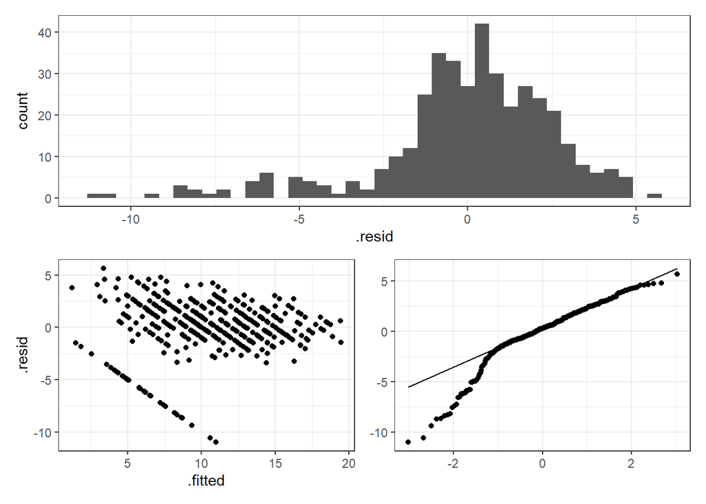

```r
plot_diag <- function(df) {
  p1 <- ggplot(df, aes(.resid)) +
    geom_histogram(bins = 40)


  p2 <- ggplot(df, aes(.fitted, .resid)) +
    geom_point()

  p3 <- ggplot(df, aes(sample = .resid)) +
    geom_qq_line() +
    geom_qq() +
    labs(x = NULL, y = NULL)

  p1 / (p2 + p3)
}

broom::augment(mod1) %>%
  plot_diag()
```

Was ist mit der schrägen Linie in den Residuen?

```r
broom::augment(mod1) %>%
  arrange(.resid) %>%
  select(FinalScore:G1, .fitted, .resid) %>%
  head(30) %>%
  knitr::kable()
```

| FinalScore | school | sex | age | reason | failures | Walc | absences | G1 | .fitted | .resid |
| --- | --- | --- | --- | --- | --- | --- | --- | --- | --- | --- |
| 0 | GP | F | 15 | course | 2 | 2 | 0 | 12 | 10.984826 | -10.984826 |
| 0 | GP | F | 15 | course | 0 | 1 | 0 | 11 | 10.581729 | -10.581729 |
| 0 | GP | M | 17 | course | 0 | 4 | 0 | 10 | 9.359163 | -9.359163 |
| 0 | GP | M | 15 | course | 0 | 1 | 0 | 9 | 8.686982 | -8.686982 |
| 0 | GP | F | 17 | course | 0 | 1 | 0 | 10 | 8.615232 | -8.615232 |
| 0 | GP | F | 19 | reputation | 0 | 3 | 0 | 10 | 8.361429 | -8.361429 |
| 0 | GP | M | 18 | home | 1 | 2 | 0 | 10 | 8.264572 | -8.264572 |
| 0 | GP | F | 18 | course | 0 | 1 | 0 | 10 | 8.166006 | -8.166006 |
| 0 | GP | F | 15 | course | 0 | 2 | 0 | 8 | 7.545124 | -7.545124 |
| 0 | GP | F | 17 | home | 1 | 2 | 0 | 9 | 7.404411 | -7.404411 |
| 0 | GP | F | 18 | home | 0 | 1 | 0 | 9 | 7.203894 | -7.203894 |
| 0 | GP | M | 15 | course | 0 | 1 | 0 | 7 | 6.550892 | -6.550892 |
| 0 | GP | F | 19 | home | 1 | 2 | 0 | 9 | 6.505959 | -6.505959 |
| 0 | GP | F | 18 | course | 0 | 2 | 0 | 8 | 6.197446 | -6.197446 |
| 0 | GP | M | 16 | course | 1 | 4 | 0 | 7 | 6.188015 | -6.188015 |
| 0 | GP | F | 18 | home | 0 | 1 | 0 | 8 | 6.135849 | -6.135849 |
| 0 | GP | M | 16 | course | 0 | 1 | 0 | 7 | 6.101666 | -6.101666 |
| 0 | MS | F | 17 | reputation | 1 | 2 | 0 | 7 | 5.853093 | -5.853093 |
| 0 | GP | F | 17 | home | 0 | 3 | 0 | 7 | 5.852089 | -5.852089 |
| 0 | GP | F | 16 | home | 3 | 1 | 0 | 8 | 5.785585 | -5.785585 |
| 0 | GP | M | 18 | reputation | 1 | 5 | 0 | 7 | 5.766683 | -5.766683 |
| 0 | GP | F | 18 | home | 0 | 1 | 0 | 7 | 5.067804 | -5.067804 |
| 0 | GP | M | 16 | course | 0 | 1 | 0 | 6 | 5.033621 | -5.033621 |
| 0 | GP | M | 17 | course | 2 | 2 | 0 | 7 | 4.987493 | -4.987493 |
| 0 | GP | F | 18 | course | 0 | 1 | 0 | 7 | 4.961872 | -4.961872 |
| 0 | MS | M | 19 | other | 1 | 3 | 0 | 6 | 4.937716 | -4.937716 |
| 0 | GP | F | 16 | home | 0 | 1 | 0 | 6 | 4.898211 | -4.898211 |
| 0 | GP | M | 18 | reputation | 2 | 2 | 0 | 7 | 4.847857 | -4.847857 |
| 0 | GP | M | 16 | course | 2 | 4 | 0 | 6 | 4.703732 | -4.703732 |
| 0 | MS | F | 19 | course | 1 | 2 | 0 | 7 | 4.645051 | -4.645051 |

Fälle mit aus bisher unerklärlichen Gründen finalScore von 0, wo deutlich höherer Score vorhergesagt wird.

## i. Which of the features are significant (alpha = 0:05) and how can they be interpreted (interpretation for each significant feature separately!)?

- Age: for each additional year in age, final grade is 0.4492259 *lower* (cet. par.)
- Failures: for each additional past failure, final grade is 0.4162385 *lower* (cet. par.)
- Absences: for each additional absence, final grade is 0.045308 *higher* (cet. par.). this is a bit counter-intuitive.
- G1: for each additional point in the first period grade, final grade is 1.0680448 *higher* (cet. par.).

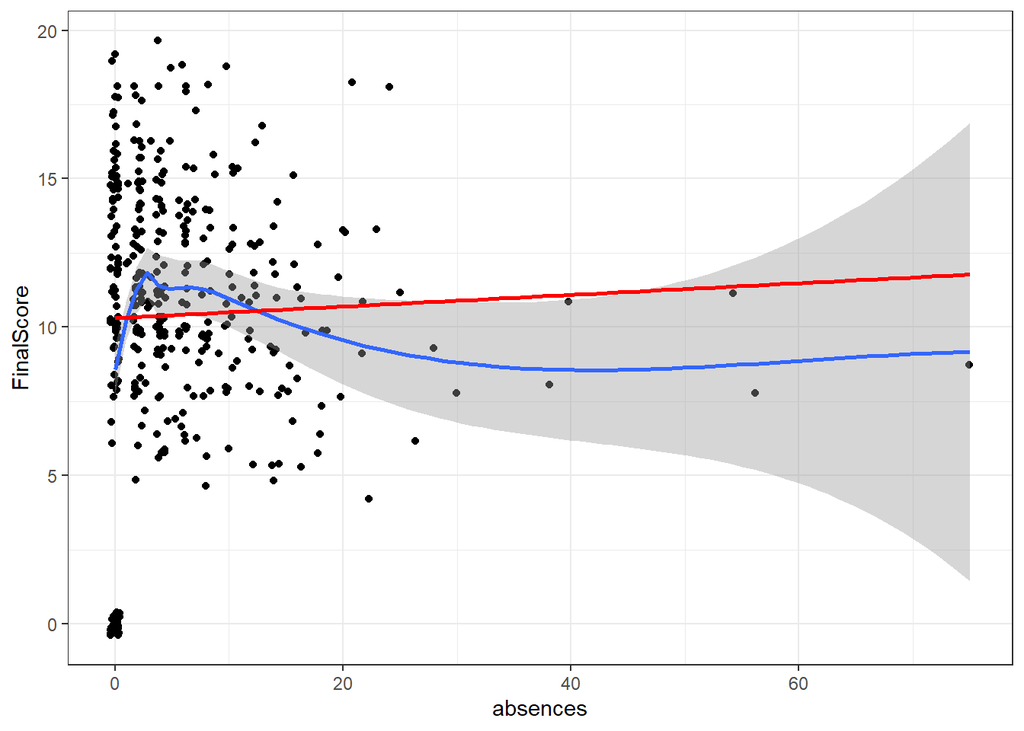

```r
ggplot(grades, aes(absences, FinalScore)) +
  geom_jitter() +
  geom_smooth() +
  geom_smooth(method = "lm", se = FALSE, colour = "red")
```

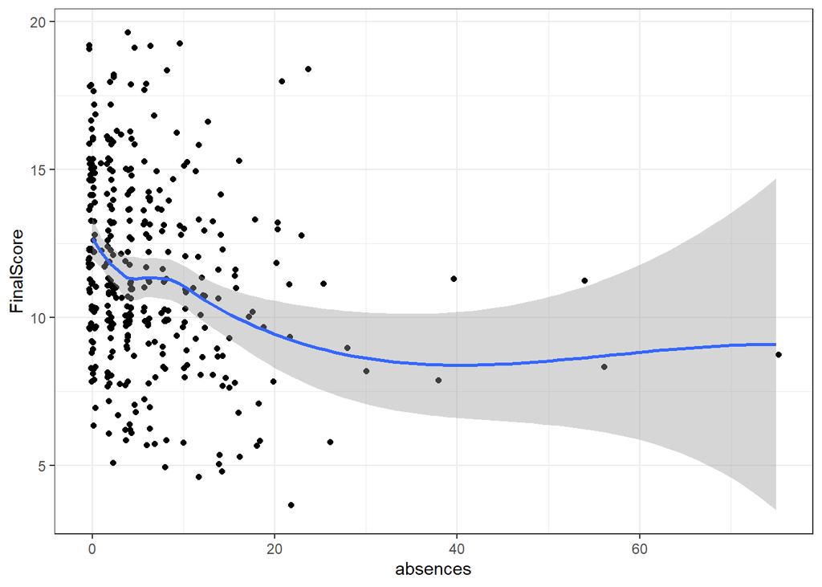

```r
grades %>%
  filter(FinalScore > 0) %>%
  ggplot(aes(absences, FinalScore)) +
  geom_jitter() +
  geom_smooth()
```

## ii. By how much is the FinalScore of male students in school ‘MS‘ higher/lower than that of male in school ‘GP‘ provided that the other features remain unchanged?

Final score is 0.3811148 higher.

## iii. By how much is the FinalScore of male students in school ‘MS‘ higher/lower than that of female in school ‘GP‘ provided that the other features remain unchanged?

```r
coef(mod1)[["schoolMS"]] + coef(mod1)[["sexM"]]
```

```
## [1] 0.6224573
```

## iv. By how much does the FinalScore change if the first period grade ‘G1‘ changes by 5 units?

```r
coef(mod1)[["G1"]] * 5
```

```
## [1] 5.340224
```

## v. How large is the estimated FinalScore of a male student in school ‘MS‘ at age 17 who has chosen this school because of reputation, never consumes alcohol on weekends, but has 50 absences and no failures, and a first period grade of 10?

```r
pred_base <- data.frame(
  sex = "M",
  school = "MS",
  age = 17,
  reason = "reputation",
  Walc = 0,
  absences = 50,
  failures = 0,
  G1 = 10
)

first_pred <- predict(mod1, newdata = pred_base)
first_pred
```

```
##        1
## 11.64515
```

## vi. By how much does the FinalScore change if ‘failures‘ increase by 2 units

```r
second_pred <- pred_base %>%
  mutate(failures = failures + 2) %>%
  predict(mod1, newdata = .)
second_pred
```

```
##        1
## 10.81267
```

```r
# alternative
coef(mod1)[["failures"]] * 2
```

```
## [1] -0.8324769
```

```r
second_pred - first_pred
```

```
##          1
## -0.8324769
```

FinalScore is lower

## vii. How large is R2?

```r
summary(mod1)$r.squared
```

```
## [1] 0.6722702
```

## viii. Determine the 95% confidence interval for the parameter of age.

```r
confint(mod1)
```

```
##                        2.5 %      97.5 %
## (Intercept)       1.45430811  9.35388251
## schoolMS         -0.53079632  1.29302595
## sexM             -0.31933782  0.80202284
## age              -0.68483284 -0.21361903
## reasonhome       -0.56602449  0.77788954
## reasonother      -0.02977179  1.93344790
## reasonreputation -0.37758891  0.99676943
## failures         -0.80872929 -0.02374763
## Walc             -0.05306304  0.38812163
## absences          0.01049474  0.08012123
## G1                0.98160578  1.15448391
```

```r
# calculate conf.int by hand
# get coefficient
beta <- coef(mod1)[["age"]]

# get t value
t_value <- qt(.975, nrow(grades) - length(coef(mod1)))
# caution: value in output is test-statistic for whether beta == 0.
# we need theoretical quantile for our conf.int
# # degrees of freedom: n - k - 1 with k = number of variables in model

std_dev <- summary(mod1)$coefficients["age", "Std. Error"]

# lower
beta - t_value * std_dev
```

```
## [1] -0.6848328
```

```r
# upper
beta + t_value * std_dev
```

```
## [1] -0.213619
```

# (b) Estimate a new regression model with the same features and the following additional features:

1. failures2
2. log1p(absences)
3. interaction of absences and failures

```r
mod2 <- update(mod1, . ~ . + I(failures^2) + log1p(absences) + absences:failures)
summary(mod2)
```

```
##
## Call:
## lm(formula = FinalScore ~ school + sex + age + reason + failures +
##     Walc + absences + G1 + I(failures^2) + log1p(absences) +
##     failures:absences, data = grades)
##
## Residuals:
##      Min       1Q   Median       3Q      Max
## -10.0038  -1.1657   0.1129   1.4356   6.2480
##
## Coefficients:
##                   Estimate Std. Error t value Pr(>|t|)
## (Intercept)        5.64958    1.89671   2.979 0.003081 **
## schoolMS           0.58098    0.43386   1.339 0.181335
## sexM               0.24463    0.26623   0.919 0.358734
## age               -0.47353    0.11257  -4.207 3.23e-05 ***
## reasonhome         0.13733    0.31874   0.431 0.666821
## reasonother        0.64479    0.46728   1.380 0.168436
## reasonreputation   0.23332    0.32760   0.712 0.476772
## failures          -2.53097    0.60188  -4.205 3.26e-05 ***
## Walc               0.06146    0.10588   0.580 0.561967
## absences          -0.10614    0.02769  -3.833 0.000148 ***
## G1                 1.03598    0.04125  25.116  < 2e-16 ***
## I(failures^2)      0.66331    0.21116   3.141 0.001813 **
## log1p(absences)    1.23417    0.20888   5.908 7.67e-09 ***
## failures:absences  0.09096    0.02605   3.492 0.000537 ***
## ---
## Signif. codes:  0 '***' 0.001 '**' 0.01 '*' 0.05 '.' 0.1 ' ' 1
##
## Residual standard error: 2.477 on 381 degrees of freedom
## Multiple R-squared:  0.7173, Adjusted R-squared:  0.7076
## F-statistic: 74.35 on 13 and 381 DF,  p-value: < 2.2e-16
```

# i. What is R2 now?

```r
summary(mod2)$r.squared
```

```
## [1] 0.7172595
```

# ii. How does the FinalScore change, if failures change by 1 unit while the other features remain unchanged?

# iii. How does the FinalScore change, if absences change by 1 unit while the other features remain unchanged?

```r
failres_absences <- pred_base %>%
  mutate(failures = list(0:3),
         absences = list(c(0, 5, 10, 20, 50))) %>%
  unnest(failures) %>%
  unnest(absences) %>%
  broom::augment(mod2, newdata = .) %>%
  select(failures, absences, .fitted) %>%
  mutate(diff = .fitted - lag(.fitted),
         diff = case_when(failures == 0 ~ NA_real_,
                          TRUE ~ diff)) %>%
  arrange(absences)

failres_absences %>%
  knitr::kable()
```

| failures | absences | .fitted | diff |
| --- | --- | --- | --- |
| 0 | 0 | 9.018242 | NA |
| 1 | 0 | 7.150587 | -1.4129836 |
| 2 | 0 | 6.609558 | -4.6344675 |
| 3 | 0 | 7.395153 | -7.8559514 |
| 0 | 5 | 10.698850 | NA |
| 1 | 5 | 9.286006 | 2.1354190 |
| 2 | 5 | 9.199787 | 2.5902298 |
| 3 | 5 | 10.440193 | 3.0450407 |
| 0 | 10 | 10.916202 | NA |
| 1 | 10 | 9.958170 | 0.6721633 |
| 2 | 10 | 10.326762 | 1.1269741 |
| 3 | 10 | 12.021978 | 1.5817850 |
| 0 | 20 | 10.652808 | NA |
| 1 | 20 | 10.604397 | 0.6462278 |
| 2 | 20 | 11.882611 | 1.5558495 |
| 3 | 20 | 14.487449 | 2.4654712 |
| 0 | 50 | 8.563571 | NA |
| 1 | 50 | 11.244025 | 0.6396277 |
| 2 | 50 | 15.251104 | 3.3684928 |
| 3 | 50 | 20.584807 | 6.0973580 |

# iv. How can we interpret the interaction term? Is it significant and what does this mean?

It is significant.

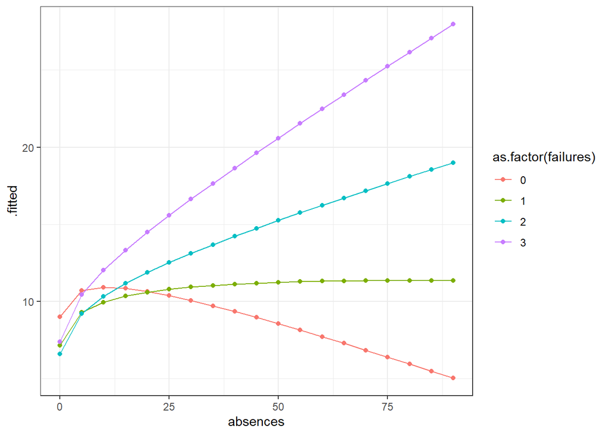

```r
pred_base %>%
  mutate(absences = list(seq(0, 93, by = 5)),
         failures = list(0:3)) %>%
  unnest(failures) %>%
  unnest(absences) %>%
  broom::augment(mod2, newdata = .) %>%
  ggplot(aes(absences, .fitted, colour = as.factor(failures))) +
  geom_line() +
  geom_point()
```

```r
max(grades$absences)
```

```
## [1] 75
```

# v. How large is the estimated FinalScore of a male student in school ‘MS‘ at age 17 who has chosen this school because of reputation, never consumes alcohol on weekends, but has 50 absences and no failures, and a first period grade of 10?

```r
third_pred <- predict(mod2, newdata = pred_base)
third_pred
```

```
##        1
## 8.563571
```

```r
first_pred - third_pred
```

```
##        1
## 3.081579
```

Der vorhergesagte Wert ist niedriger als beim ersten Modell.

# vi. How large is the standard deviation ? Is it smaller or larger than in the previous model?

```r
summary(mod1)$sigma
```

```
## [1] 2.656701
```

```r
summary(mod2)$sigma
```

```
## [1] 2.477319
```

Kleiner.

### Fehlspezifikation beheben

```r
clean_data <- grades %>%
  filter(FinalScore > 0)

mod3 <-  update(mod2, data = clean_data)

summary(mod3)
```

```
##
## Call:
## lm(formula = FinalScore ~ school + sex + age + reason + failures +
##     Walc + absences + G1 + I(failures^2) + log1p(absences) +
##     failures:absences, data = clean_data)
##
## Residuals:
##     Min      1Q  Median      3Q     Max
## -4.0264 -0.9932  0.0294  1.0300  3.6660
##
## Coefficients:
##                    Estimate Std. Error t value Pr(>|t|)
## (Intercept)        5.208782   1.139299   4.572 6.76e-06 ***
## schoolMS          -0.506473   0.258774  -1.957  0.05113 .
## sexM               0.059076   0.157216   0.376  0.70732
## age               -0.184039   0.068784  -2.676  0.00782 **
## reasonhome         0.148032   0.192464   0.769  0.44234
## reasonother        0.357000   0.269132   1.326  0.18556
## reasonreputation  -0.060083   0.193721  -0.310  0.75663
## failures          -0.142960   0.404439  -0.353  0.72395
## Walc              -0.040249   0.062368  -0.645  0.51914
## absences          -0.020629   0.016032  -1.287  0.19906
## G1                 0.872340   0.024750  35.246  < 2e-16 ***
## I(failures^2)      0.082932   0.138224   0.600  0.54891
## log1p(absences)   -0.172351   0.128185  -1.345  0.17966
## failures:absences  0.001328   0.016875   0.079  0.93734
## ---
## Signif. codes:  0 '***' 0.001 '**' 0.01 '*' 0.05 '.' 0.1 ' ' 1
##
## Residual standard error: 1.396 on 343 degrees of freedom
## Multiple R-squared:  0.8198, Adjusted R-squared:  0.813
## F-statistic: 120.1 on 13 and 343 DF,  p-value: < 2.2e-16
```

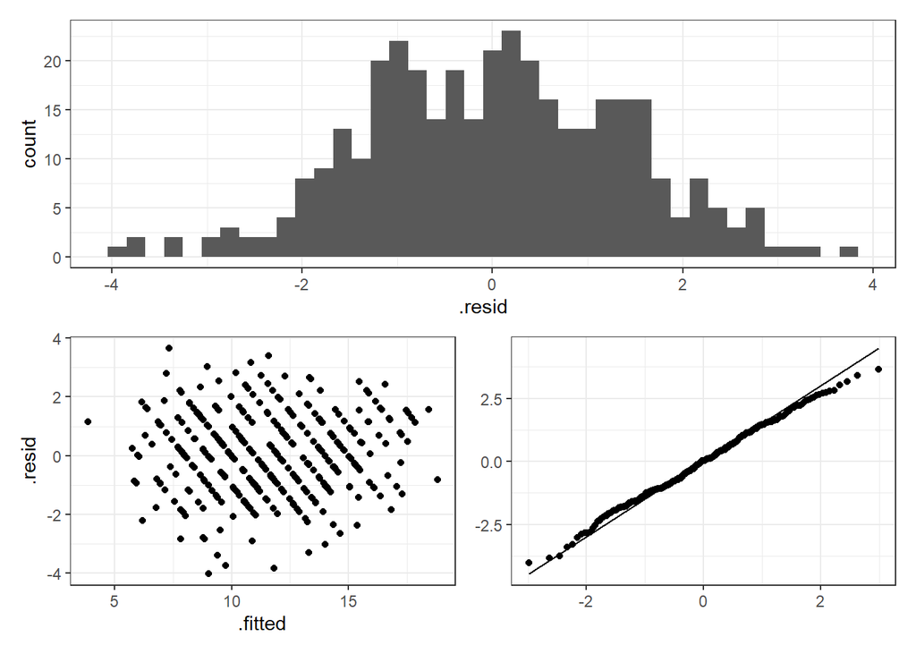

```r
broom::augment(mod3) %>%
  plot_diag()
```

```r
mod1_rev <-  update(mod1, data = clean_data)
AIC(mod1_rev, mod3)
```

```
##          df      AIC
## mod1_rev 12 1263.289
## mod3     15 1266.923
```

```r
summary(mod1_rev)
```

```
##
## Call:
## lm(formula = FinalScore ~ ., data = clean_data)
##
## Residuals:
##     Min      1Q  Median      3Q     Max
## -4.0697 -1.0018  0.0228  0.9907  3.6055
##
## Coefficients:
##                   Estimate Std. Error t value Pr(>|t|)
## (Intercept)       5.205465   1.126538   4.621  5.4e-06 ***
## schoolMS         -0.485549   0.257239  -1.888 0.059924 .
## sexM              0.050076   0.156874   0.319 0.749759
## age              -0.193464   0.068054  -2.843 0.004737 **
## reasonhome        0.142311   0.191695   0.742 0.458358
## reasonother       0.336288   0.268020   1.255 0.210431
## reasonreputation -0.080945   0.192384  -0.421 0.674200
## failures          0.058017   0.121098   0.479 0.632172
## Walc             -0.048208   0.061761  -0.781 0.435599
## absences         -0.037760   0.009773  -3.864 0.000133 ***
## G1                0.874928   0.024644  35.502  < 2e-16 ***
## ---
## Signif. codes:  0 '***' 0.001 '**' 0.01 '*' 0.05 '.' 0.1 ' ' 1
##
## Residual standard error: 1.394 on 346 degrees of freedom
## Multiple R-squared:  0.8186, Adjusted R-squared:  0.8134
## F-statistic: 156.2 on 10 and 346 DF,  p-value: < 2.2e-16
```

# (c) Find a quantile regression for the quantiles 0.05, 0.25, 0.5, 0.75, 0.95. How can we interpret the results? Is a quantile regression justified?

```r
library(quantreg)
mod_quant <- rq(FinalScore ~ ., tau = c(.05, .25, .5, .75, .95), data = grades)
summary(mod_quant)
```

```
##
## Call: rq(formula = FinalScore ~ ., tau = c(0.05, 0.25, 0.5, 0.75, 0.95),
##     data = grades)
##
## tau: [1] 0.05
##
## Coefficients:
##                  coefficients   lower bd       upper bd
## (Intercept)       -1.853830e+00  -4.429140e+00   1.344310e+01
## schoolMS           1.190520e+00  -3.493600e-01   3.007690e+00
## sexM               1.733040e+00   1.070000e-02   2.574690e+00
## age               -7.005100e-01  -1.287000e+00  -5.328200e-01
## reasonhome         1.103720e+00  -1.055200e-01   3.746390e+00
## reasonother        1.969660e+00 -1.797693e+308   5.471760e+00
## reasonreputation   1.743980e+00   5.593000e-01   5.161480e+00
## failures          -5.091000e-02  -2.898990e+00   4.902800e-01
## Walc               2.504700e-01  -1.755400e-01   7.935500e-01
## absences           1.046000e-01   9.105000e-02   1.078700e-01
## G1                 1.482570e+00   1.270120e+00   1.590400e+00
##
## Call: rq(formula = FinalScore ~ ., tau = c(0.05, 0.25, 0.5, 0.75, 0.95),
##     data = grades)
##
## tau: [1] 0.25
##
## Coefficients:
##                  coefficients lower bd upper bd
## (Intercept)       0.10011     -1.55728  1.57183
## schoolMS          0.03583     -0.97142  0.53860
## sexM              0.04004     -0.29693  0.41520
## age              -0.13277     -0.25723 -0.00666
## reasonhome        0.06744     -0.17496  0.61841
## reasonother       0.39621     -0.10521  1.46839
## reasonreputation  0.30348     -0.02275  0.67269
## failures         -1.13804     -1.62505 -0.70489
## Walc              0.11591     -0.01482  0.20055
## absences          0.01475      0.00856  0.03086
## G1                1.04636      1.01935  1.14472
##
## Call: rq(formula = FinalScore ~ ., tau = c(0.05, 0.25, 0.5, 0.75, 0.95),
```

[output cut: 40 more lines]

```
## tau: [1] 0.95
##
## Coefficients:
##                  coefficients   lower bd       upper bd
## (Intercept)        8.857090e+00   7.687420e+00   1.265389e+01
## schoolMS          -4.475600e-01  -8.559200e-01   3.236400e-01
## sexM               3.771000e-01   5.613000e-02   8.225200e-01
## age               -2.892300e-01  -5.630400e-01  -2.115700e-01
## reasonhome         4.085300e-01  -9.211000e-02   7.891800e-01
## reasonother        7.826000e-02  -4.508300e-01  1.797693e+308
## reasonreputation  -1.319100e-01  -6.175100e-01   5.218900e-01
## failures          -1.010800e-01  -1.913800e-01   5.318700e-01
## Walc               2.082000e-02  -2.313100e-01   1.728600e-01
## absences          -3.102000e-02  -4.826000e-02   4.597000e-02
## G1                 8.546800e-01   7.912000e-01   9.190100e-01
```